# Modeling the Impact: When Data Hits Hard

Author

Tom Spencer, Luis Batista Tome, Matt Copland, Michael Fehl

*Abstract*:

We assess whether routinely collected crash, vehicle and environmental variables can predict driver injury severity in U.S. crash microdata. We frame injury severity as a three-class classification problem (No Injury, Injured, Fatal) and compare penalized multinomial regression and tree-based methods under a leak-safe preprocessing pipeline. A core contribution is disciplined variable construction: we collapse high-cardinality administrative codes into interpretable groups, preserve “unknown/not reported” information when it may be informative, and prevent within-crash leakage via grouped splitting by crash ID. Performance is reported using class-balanced metrics and confusion matrices to reflect the imbalanced nature of severe outcomes.

# 1. Intro

## Prediction Problem/Idea

Predicting injury severity in traffic crashes supports road safety policy, vehicle regulation, and post-crash response. However, severity outcomes reflect heterogeneous mechanisms and strong interactions between driver behavior, vehicle protection, and environmental context.

In this project we predict driver-level injury severity using supervised learning. Beyond raw accuracy, we emphasize (i) leak-safe preprocessing, (ii) interpretable and stable feature engineering and (iii) evaluation metrics appropriate for multiclass, imbalanced outcomes.

## Base Filtering

We restrict the analysis to drivers only (PER_TYP == 1). This aligns the unit of analysis with the prediction target, avoids mixing occupants with fundamentally different exposure and protection and reduces within-crash dependence introduced by multiple passengers.

### Data Description:

Our data is sourced from the National Highway Traffic Safety Administration, part of the U.S. Department of Transportation, found at: [Check the NHTSA Data](https://www.nhtsa.gov/research-data/fatality-analysis-reporting-system-far). They release yearly public reports on car crash statistics, in which we accessed the 2023 crash data. The dataset (after for filtering on drivers only) has the following dimensions:

```
[1] "Observations:  57939 Variables:  57"
```

# 2. Data Exploration

**Missingness and sentinel codes.** Many fields use dataset-specific sentinel values to represent missing, unknown, or not reported information rather than explicit NA. We recode these systematically. For categorical predictors, we retain an explicit “unknown” level when non-reporting may itself be informative. For numeric predictors, we convert invalid/sentinel values to NA to preserve numeric meaning and handle missingness later in the modeling pipeline.

**Dual-role variables.** When a concept has both a categorical “status” representation and a numeric “magnitude” representation (e.g., alcohol test status vs. measured BAC), we separate them: a categorical feature captures reporting/test status, while the numeric measurement is retained only when valid.

### Variable Cleaning

This section documents the final predictor representations used for modeling. We simplify high-cardinality administrative codes into substantively meaningful groups, preserve an explicit “unknown” level for categorical predictors when reporting may be informative and avoid imposing artificial ordering on nominal variables. Where numeric variables contain invalid or sentinel codes, we recode these to NA and handle missingness within the recipe to prevent leakage.

#### INJ_SEV

This is our outcome variable and records the severity of the injury sustained by the driver in the crash. We recode injury severity into three classes (No Injury, Injured, Fatal) to define a clear multiclass prediction task. Observations with unknown injury severity are removed.

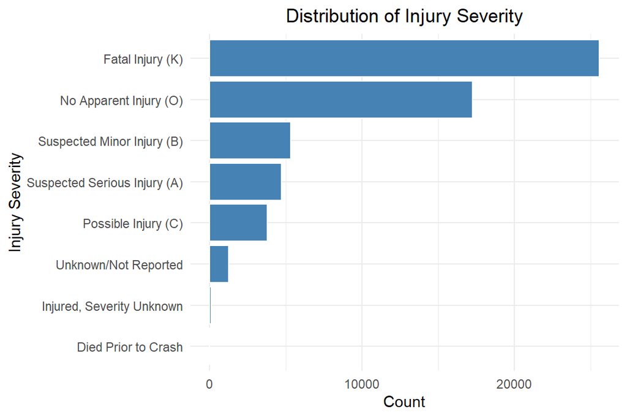

```
# A tibble: 3 × 3
  INJ_SEV   Count Percentage
  <fct>     <int>      <dbl>
1 No Injury 17242       30.5
2 Injured   13777       24.3
3 Dead      25578       45.2
```

After restricting to drivers and recoding injury severity into three classes, the outcome is moderately imbalanced, with fatalities (“Dead”) forming the largest share (~45%), which motivates using stratified splits and class-balanced evaluation metrics.

#### VE_TOTAL

VE_TOTAL records the total number of vehicles involved in the crash. We keep it as a numeric count of vehicles involved in the crash. The variable is interpretable and captures an important mechanism: multi-vehicle crashes may differ systematically from single-vehicle crashes in both impact dynamics and exposure to secondary collisions.

```
Number of outliers: 3484
```

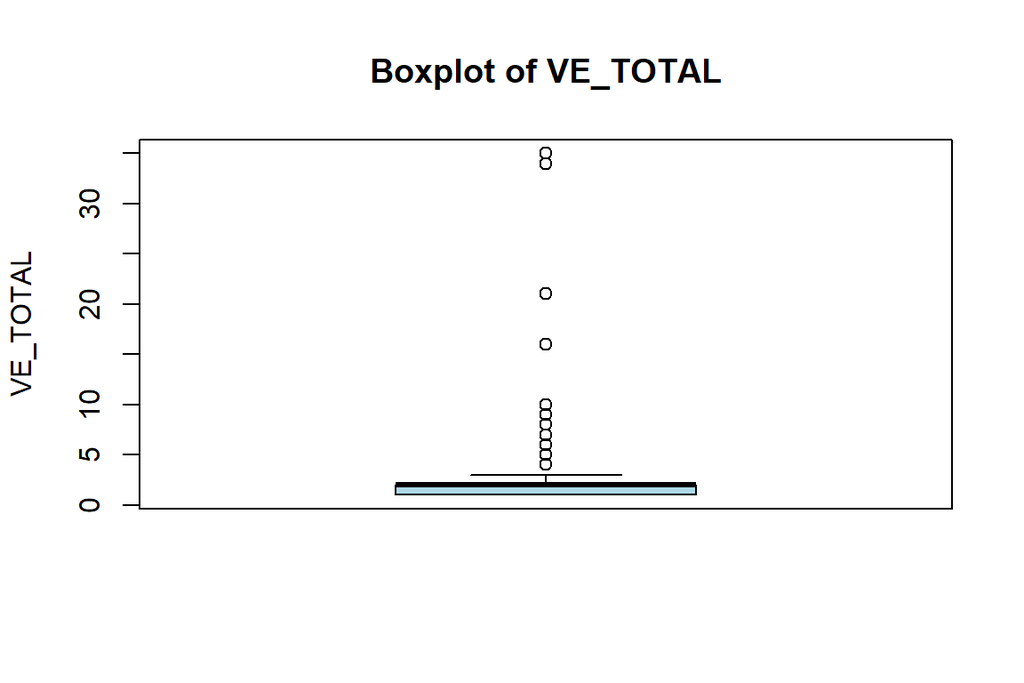

High values are plausible in large pileups and are retained.

#### HOUR

HOUR is treated as cyclical time. Invalid hour codes are set to missing and imputed within the recipe, and we encode hour using sine/cosine transformations so that late-night and early-morning hours are represented as close in feature space.

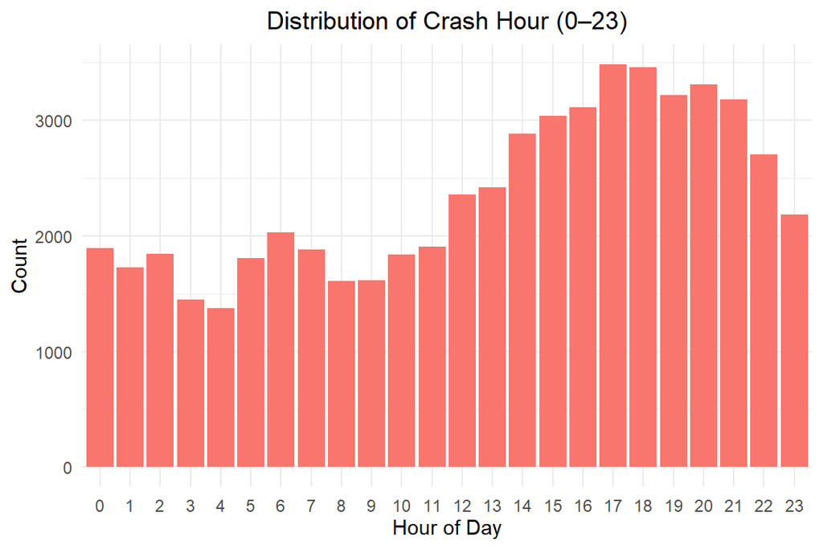

Crash frequency varies systematically over the day, with lower counts overnight and higher incidence during afternoon and early evening periods

#### DAY

Day-of-month shows little systematic structure across the calendar days, so we reduce dimensionality by recoding to day of week. This better captures recurring traffic patterns (weekday commuting vs. weekend travel) while avoiding an arbitrary 1–31 scale.

#### ROUTE

Roadway type contains many low-frequency categories. We group route codes into broader road hierarchy categories to reduce sparsity while preserving interpretable differences in speed environment and traffic mix.

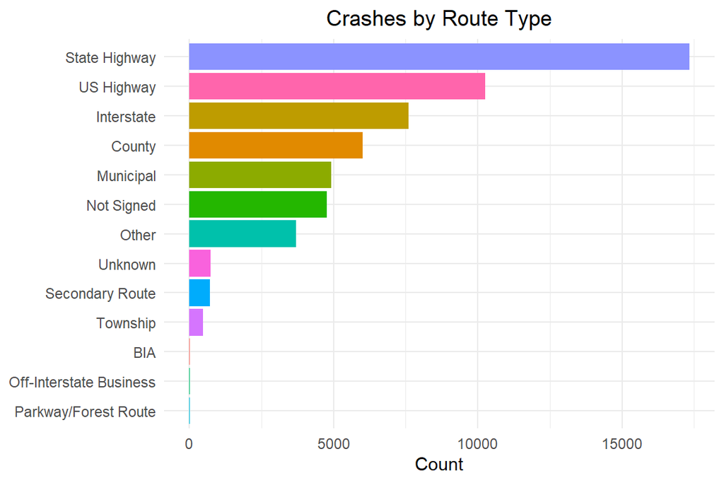

#### HARM_EV

The first harmful event includes many detailed mechanisms. We collapse categories into broader, mechanism-based groups (e.g., other motor vehicle, non-motorist, run-off-road, barrier/guardrail) to stabilize estimates and improve interpretability.

```
# A tibble: 11 × 2
   HARM_EV                     n
   <fct>                   <int>
 1 Other Motor Vehicle     33737
 2 Non-Motorist             8222
 3 Run-off-Road             3149
 4 Non-Collision            2932
 5 Tree/Vegetation          2541
 6 Barrier/Guardrail        1789
 7 Roadside Structure       1603
 8 Utility/Traffic Support  1571
 9 Other Object              621
10 Unknown/Other             321
11 Rail Incident             111
```

#### MAN_COLL

Collision manner is simplified by merging rare or substantively similar categories. The goal is to preserve the main collision geometries (e.g., angle, front-to-front, front-to-rear) while avoiding sparse levels that destabilize model training.

```
# A tibble: 9 × 2
  MAN_COLL                            n
  <fct>                           <int>
1 Non-Vehicle Collision           23352
2 Angle                           14845
3 Front-to-Front                   8967
4 Front-to-Rear                    6553
5 Sideswipe -- Same Direction      1412
6 Sideswipe -- Opposite Direction   981
7 Other                             212
8 Unknown                           208
9 Rear-to-Side                       67
```

#### RUR_URB

We retain a three-level factor (Urban, Rural, Unknown), merging administrative/non-informative codes into Unknown.

```
# A tibble: 3 × 2
  RUR_URB     n
  <chr>   <int>
1 Rural   22610
2 Unknown   368
3 Urban   33619
```

#### LGT_COND

LGT_COND contains detailed and occasionally ambiguous lighting categories. To reduce sparsity and improve interpretability, lighting conditions are recoded into a small set of visibility states. This representation preserves meaningful differences in visibility while yielding stable categories for modeling.

```
     LGT_SIMPLE     n percent
       daylight 28012  49.49%
 dark_no_lights 13913  24.58%
       dark_lit 11249  19.88%
   dark_unknown   543   0.96%
       twilight  2617   4.62%
        unknown   263   0.46%
```

#### WEATHER

WEATHER contains detailed and infrequent categories. We collapse it into a small set of mechanism-based groups reflecting visibility and road-surface conditions, with an explicit unknown category retained to improve stability for modeling.

Because weather and lighting jointly affect visibility, their interaction is considered later during feature engineering.

```
  WEATHER_SIMPLE     n percent
 good_visibility 49454  87.38%
   precipitation  5044   8.91%
  low_visibility   191   0.34%
         unknown  1908   3.37%
```

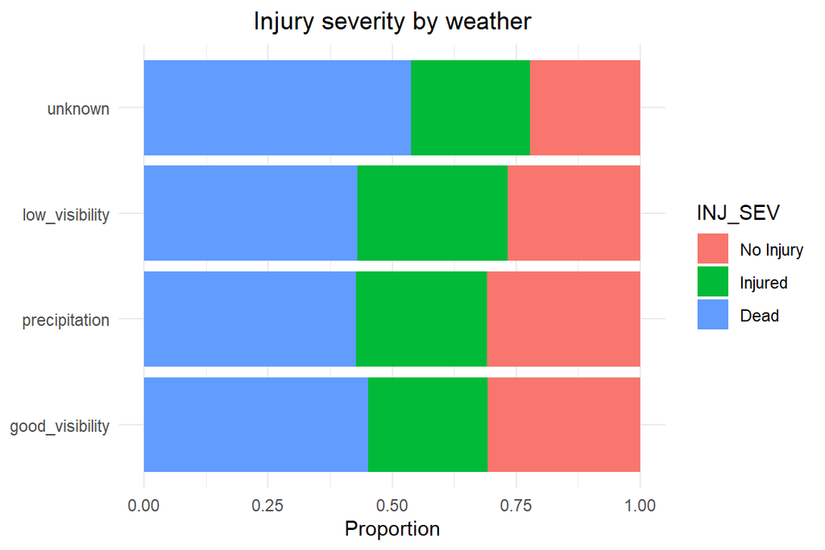

#### VEH_NO / VPICMAKENAME / VPICMODELNAME

VEH_NO is an administrative index within a crash and carries no substantive information; including it would add arbitrary ordering and could amplify within-crash dependence. VPICMAKENAME and VPICMODELNAME are high-cardinality identifiers that largely proxy for other vehicle characteristics already represented (e.g., body class and weight). To avoid sparsity and instability, we exclude these fields.

#### VPICBODYCLASSNAME

VPICBODYCLASSNAME is collapsed into: passenger_car, suv, truck, motorcycle, other, and unknown. These groups reflect fundamental differences in mass and occupant protection, reduce sparsity, and align with standard road safety categories.

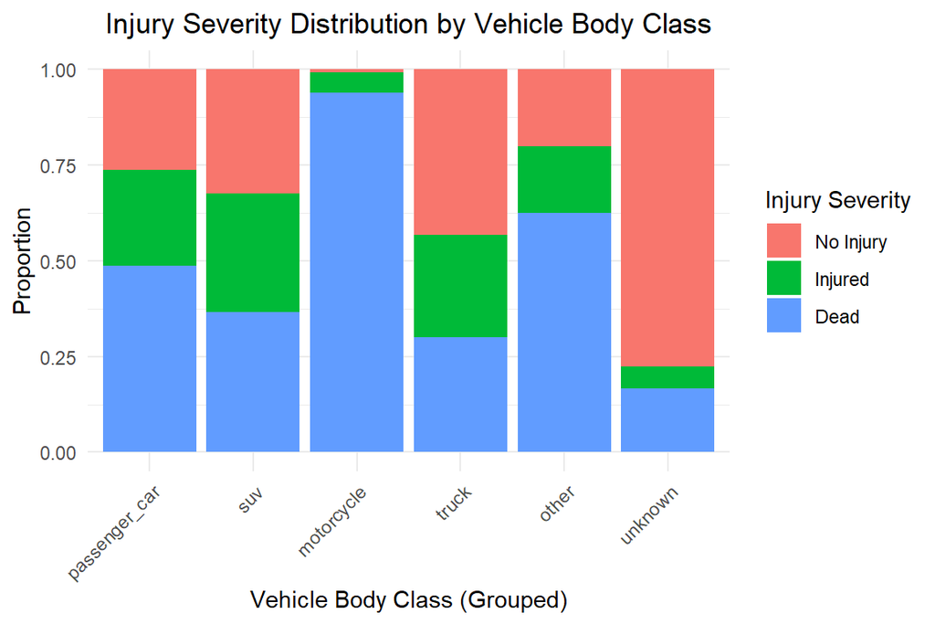

Motorcycle crashes show a significantly higher fatality share, while trucks show comparatively lower fatality shares.

#### AGE

Driver age is retained as numeric. Invalid/unreported values are recoded to NA and imputed within the recipe to retain observations without treating missingness as a numeric value.

```
   Min. 1st Qu.  Median    Mean 3rd Qu.    Max.    NA's
   7.00   28.00   40.00   43.12   57.00  103.00     798
```

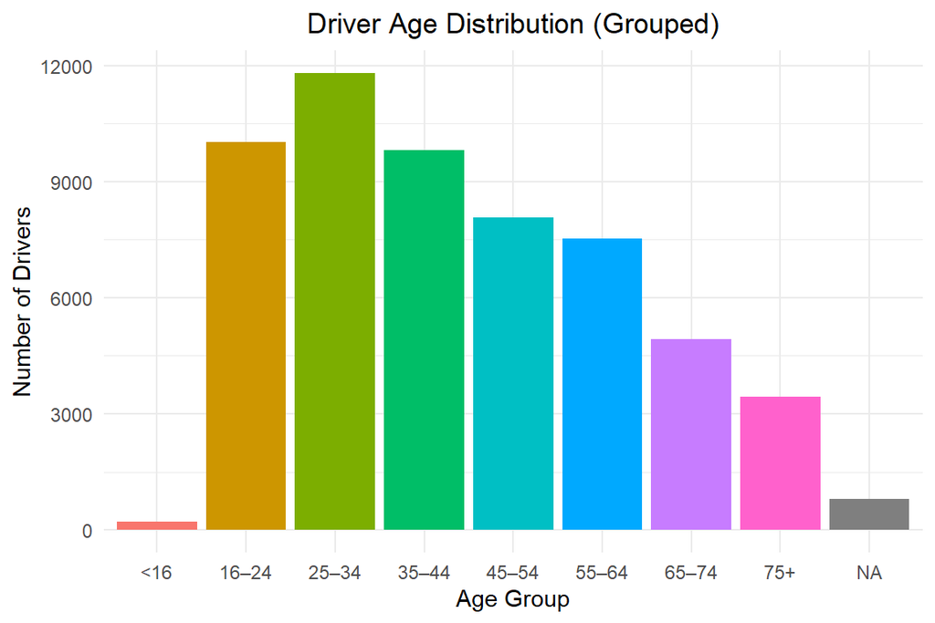

#### SEX

We recode SEX into Male, Female, and Unknown by grouping non-informative codes. This preserves all observations and yields a stable categorical predictor.

```
# A tibble: 3 × 3
  SEX         n Percent
  <fct>   <int>   <dbl>
1 Male    41768   73.8
2 Female  14063   24.8
3 Unknown   766    1.35
```

#### SEAT_POS

This variable is dropped. After restricting to drivers, seat position has essentially no variation and provides negligible predictive signal.

#### REST_USE

REST_USE is recoded into a three-level factor (restrained, unrestrained, unknown) to reduce sparsity while preserving the primary safety distinction. Injury severity differs markedly across these groups, with unrestrained drivers exhibiting a substantially higher share of fatal outcomes, consistent with expected seatbelt protection effects.

```
# A tibble: 3 × 2
  REST_SIMPLE      n
  <fct>        <int>
1 restrained   33432
2 unrestrained 17985
3 unknown       5180
```

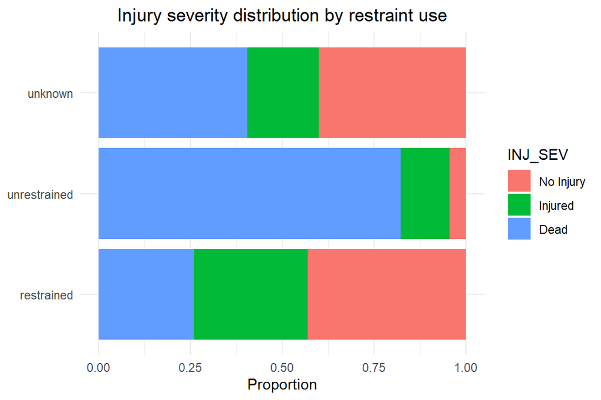

#### AIR_BAG

AIR_BAG is simplified to deployed, not_deployed, and unknown. Deployment is correlated with crash severity (high-energy impacts are more likely to deploy airbags), so its association with worse outcomes should be interpreted as reflecting crash intensity as well as protection.

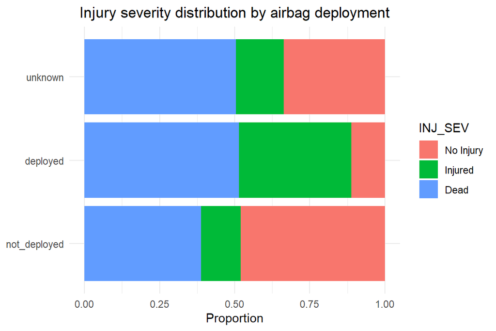

#### GVWR/WEIGHT

GVWR is mapped to broad weight classes, retaining Unknown where missing. This captures vehicle mass, a key determinant of crash forces, using stable categories suitable for modeling.

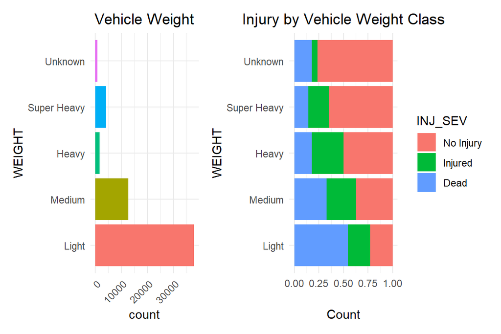

Lighter vehicle classes exhibit higher fatality shares in the data.

#### TRAV_SP

Travel speed is retained as a numeric predictor where recorded and set to NA when missing or invalid. We handle missingness and potential nonlinearity within the modeling pipeline (including binned representations used later).

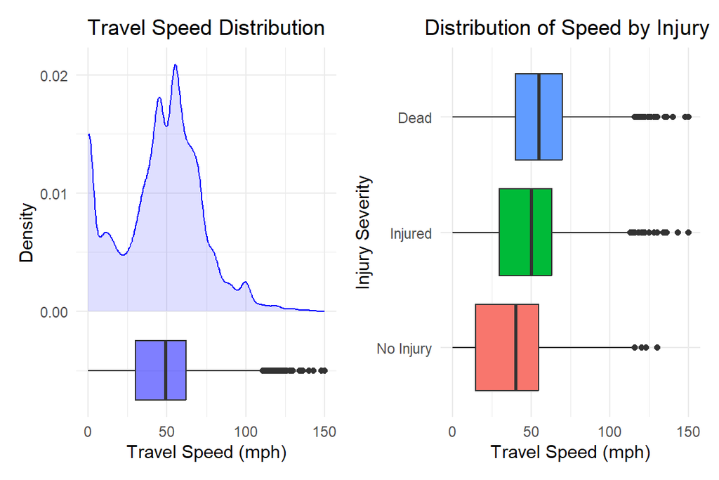

Travel speeds tend to be higher for more severe injury outcomes.

#### VSPD_LIM

Posted speed limit is retained as numeric roadway context. We later combine it with travel speed to engineer a speeding indicator (travel speed above posted limit), which is likely more informative than either measure alone.

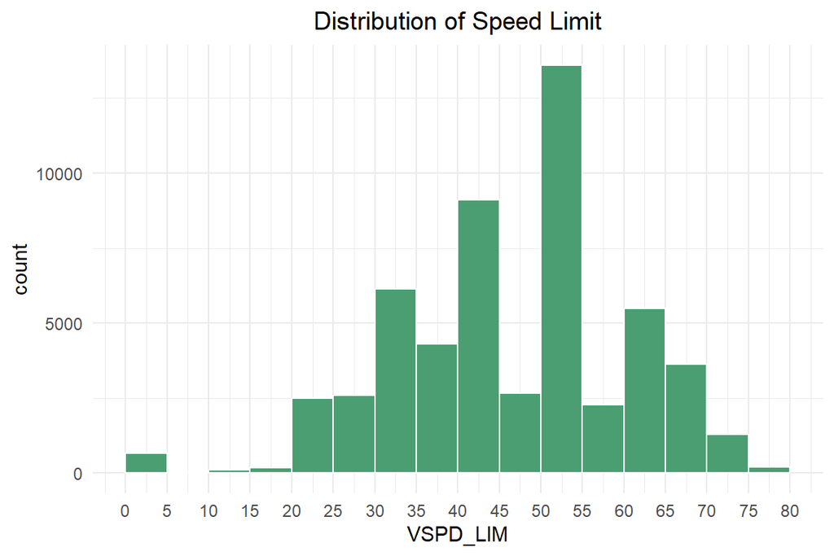

#### ROLLOVER

ROLLOVER is simplified into a binary indicator capturing whether a rollover occurred, with an explicit unknown category retained to preserve missing or unreported cases.

#### IMPACT1

The point of impact is grouped into broad sides (Front, Rear, Left, Right, Top/Under, Non-collision), with all unknown/other codes consolidated to a single level.

```
# A tibble: 7 × 3
  IMPACT1           n pct
  <fct>         <int> <chr>
1 Front         36618 64.7%
2 Rear           4393 7.8%
3 Left           5214 9.2%
4 Right          4364 7.7%
5 Top/Under       659 1.2%
6 Non-Collision  2904 5.1%
7 Other/Unknown  2445 4.3%
```

#### DEFORMED

Vehicle deformation level is retained as an ordinal proxy for impact severity, with Unknown retained to avoid implicitly dropping non-reported cases.

```
# A tibble: 5 × 3
  DEFORMED              n  prop
  <fct>             <int> <dbl>
1 Disabling Damage  37398 66.1
2 Functional Damage  4416  7.8
3 Minor Damage       3918  6.92
4 No Damage           838  1.48
5 Unknown           10027 17.7
```

#### FIRE_EXP

```
# A tibble: 2 × 3
  FIRE_EXP     n  prop
     <dbl> <int> <dbl>
1        0 54507 96.3
2        1  2090  3.69
```

#### VSURCOND

```
# A tibble: 3 × 3
  VSURCOND_SIMPLE     n  prop
  <fct>           <int> <dbl>
1 dry             47847 84.5
2 wet_icy          6737 11.9
3 unknown          2013  3.56
```

#### ALC_RES

ALC_RES encodes both measured blood alcohol concentration (BAC, stored as BAC × 1000) and administrative codes indicating that a test was not performed or the result is unknown. We therefore separate alcohol involvement into two complementary representations: a numeric BAC variable (BAC_VALUE) retained only when a valid measurement exists, and a compact categorical indicator (ALC_SIMPLE) that captures test status and retains an explicit unknown category. Summaries of the original ALC_RES codes are used descriptively to understand reporting patterns, while modeling relies on these simplified representations.

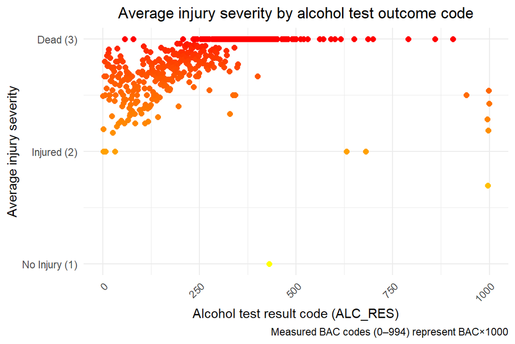

Among cases with a recorded BAC measurement, average injury severity is high, consistent with alcohol testing being more common in severe crashes.

#### DRUGS

```
# A tibble: 4 × 3
  DRUGS                       n   pct
  <fct>                   <int> <dbl>
1 No (drugs not involved) 23880 42.2
2 Not Reported            22695 40.1
3 Reported as Unknown      5730 10.1
4 Yes (drugs involved)     4292  7.58
```

# 3. Missing Data

## Missingness

Some predictors are inherently numeric and encode quantitative magnitude rather than discrete states. For such variables, retaining an “Unknown” or “Unreported” category would discard scale information and incorrectly treat non-observation as a meaningful level. We therefore examine the extent and nature of missingness in numeric variables to motivate appropriate imputation strategies. These strategies are implemented later in the recipes stage.

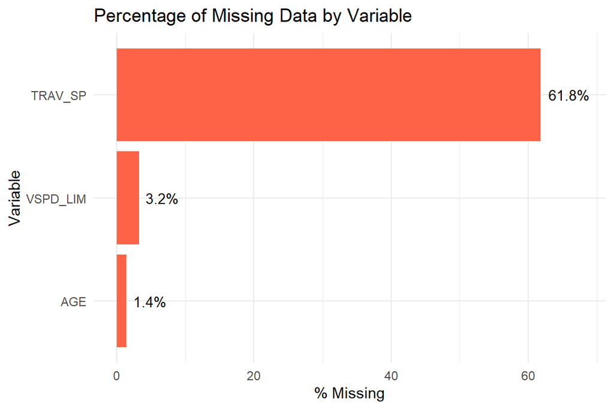

#### TRAV_SP

Travel speed is missing over 60% of observations. We expect this variable to be a very important predictor for injury severity of a crash; thus, we would like to keep this variable and handle the missing data.

```
# A tibble: 3 × 4
  INJ_SEV   total_obs missing_trav_sp percent_missing
  <fct>         <int>           <int>           <dbl>
1 Dead          25578           16978            66.4
2 Injured       13777            8107            58.8
3 No Injury     17242            9878            57.3
```

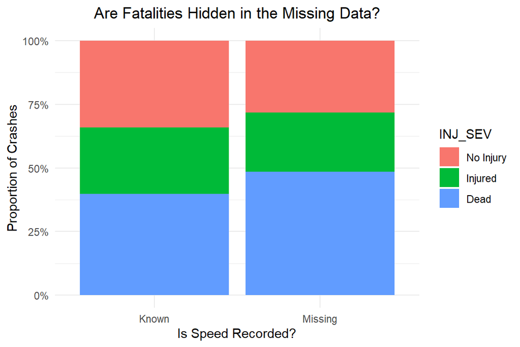

Exploration of the TRAV_SP variable suggests a non-random missingness pattern that is strongly correlated with ‘Injury Severity.’ Specifically, the data suggests that fatal outcomes are disproportionately associated with missing speed values. This informative missingness may be attributed to situational constraints at the crash scene, such as extensive vehicle damage preventing post-crash speed assessment or emergency life-saving efforts taking precedence over administrative data collection. To preserve this predictive signal, we opted for a categorical binning strategy, treating ‘Unknown’ as a distinct and meaningful level rather than imputing these values.

#### VSPD_LIM

Although ‘Speed Limit’ data was missing for 3% of observations, these values are logically deducible from the surrounding context of the crash. By leveraging the strong correlation between road type and state regulations on speed limts, a kNN imputation strategy was implemented. This approach allows the model to estimate missing speed limits by identifying similar road segments within the same jurisdiction.

```
# A tibble: 13 × 4
   ROUTE                   total_obs missing_trav_sp percent_missing
   <fct>                       <int>           <int>           <dbl>
 1 Parkway/Forest Route           11               2          18.2
 2 Off-Interstate Business        17               2          11.8
 3 BIA                            18               2          11.1
 4 Unknown                       739              57           7.71
 5 Not Signed                   4770             319           6.69
 6 Municipal                    4926             304           6.17
 7 County                       6020             323           5.37
 8 Township                      488              25           5.12
 9 US Highway                  10249             239           2.33
10 State Highway               17341             398           2.30
11 Interstate                   7595             106           1.40
12 Other                        3712              51           1.37
13 Secondary Route               711               1           0.141
```

#### AGE

Preliminary analysis indicates that ‘Age’ is non-randomly distributed across ‘Vehicle Type’ and ‘Sex.’ As a result we choose to use a kNN imputation approach to capture these localized demographic patterns, allowing the model to estimate missing ages by identifying clusters of drivers with similar characteristics.

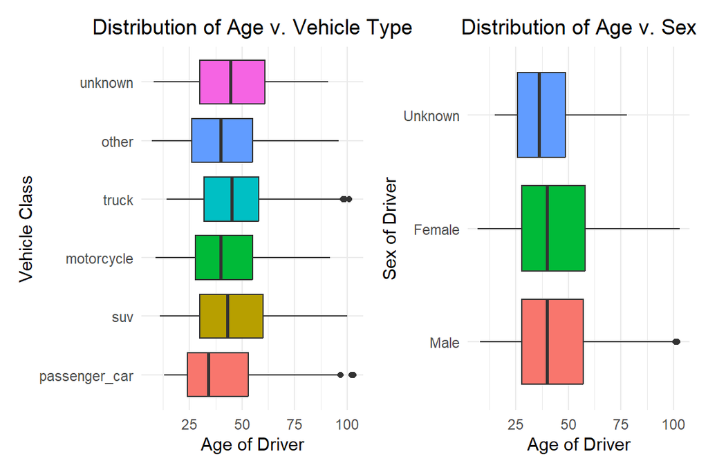

# 4. Splitting

The dataset contains multiple vehicle–driver observations from the same traffic crash, identified by `ST_CASE`. Because many predictors are shared at the crash level and outcomes are correlated within crashes, observations cannot be treated as independent. A row-level split would risk assigning vehicles from the same crash to different partitions, leading to information leakage and inflated performance estimates.

To prevent this, all data partitioning is performed **at the crash level**. Observations are grouped by `ST_CASE` so that all vehicles involved in a given crash are kept within the same split. This ensures that validation and test sets contain only entirely unseen crashes.

We first create a grouped train–test split for final evaluation. Within the training data, we then use a **single grouped validation split** for model tuning and comparison. Although full cross-validation can yield more stable estimates, it is computationally costly. Given the large sample size, a single validation split offers a practical trade-off between efficiency and reliable performance while maintaining strict separation of crashes across all splits.

## Train-test split

Our training split successfully preserves the original class distribution of INJ_SEV.

```
# A tibble: 3 × 3
  INJ_SEV       n  prop
  <fct>     <int> <dbl>
1 No.Injury 12941  30.5
2 Injured   10358  24.4
3 Dead      19149  45.1
```

# 5. Recipes pipeline

In this section, we build a preprocessing pipeline that transforms data_train into a model-ready design matrix. The recipe (i) cleans and standardizes raw inputs (e.g., recoding invalid hour values), (ii) applies the imputation strategies defined earlier for numeric variables, (iii) performs targeted feature engineering (cyclical encoding of time, a speeding flag, and a light–weather interaction with rare-level lumping), and (iv) applies standard modeling preprocessing. Implementing these steps in a single recipe ensures the same transformations are applied consistently across training, validation, and test data, while keeping preprocessing leak-safe.

## Feature Engineering

Between imputation and standard preprocessing, we introduce two targeted feature, a light–weather interaction and a speeding indicator, to capture joint environmental risk and driver risk-taking behavior that are not represented by the raw variables alone.

#### New var: LGT_WEATHER INTERACTION

To capture joint environmental effects, we create an interaction feature combining simplified light and weather conditions (`LGT_X_WEATHER`). This allows the model to learn that certain combinations (e.g. darkness with precipitation) have different risk profiles than either factor alone. Rare light–weather combinations are grouped into a `rare_combo` category to reduce sparsity and improve model stability.

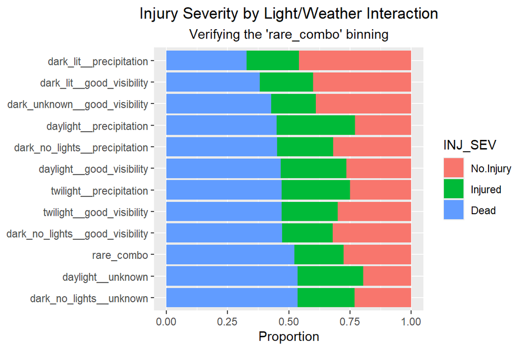

The Light × Weather interaction reveals substantial heterogeneity in injury severity across environmental condition pairings, without a clear monotonic ordering. Notably, some dark but well-lit conditions show lower fatality shares, suggesting that roadway lighting and potential behavioral responses, such as drivers reducing speed or increasing caution in perceived high-risk conditions, may mitigate injury severity. These patterns support modeling Light and Weather jointly via an interaction term, rather than imposing a single ordered “danger” index that the data do not clearly support.

#### New var: SPEEDING

Speeding is a proxy for Risk Taking. A person doing 40 in a 25 zone is likely aggressive, distracted, or reckless. This variable captures the psychology of the driver, which is a different predictor than just the force of impact. We create this dummy variable before we decide to bin the TRAV_SP, since we will drop our original TRAV_SP variable once we bin it into categories.

```
# A tibble: 2 × 3
  SPEEDING     n  prop
  <chr>    <int> <dbl>
1 No       49755  87.9
2 Yes       6842  12.1
```

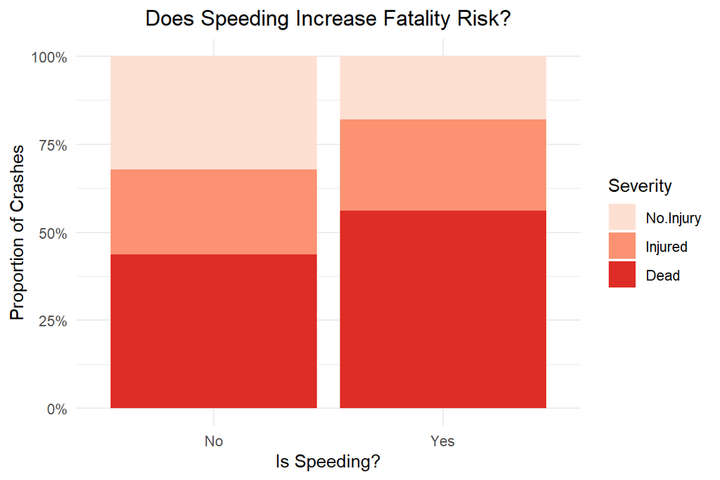

#### TRAV_SP

The transformation of TRAV_SP from a continuous numerical variable into ordered categorical bins allows for a clearer visualization of the risk profile. As illustrated in the distribution, there is a distinct **positive correlation** between higher speed cohorts and the proportion of fatal outcomes. Notably, the ‘Unknown’ category represents a significant portion of severe crashes, validating our decision to treat missingness as a distinct predictive feature rather than imputing it. This confirms that the absence of speed data is not random, but rather a characteristic of high-impact collisions where data collection was likely compromised.

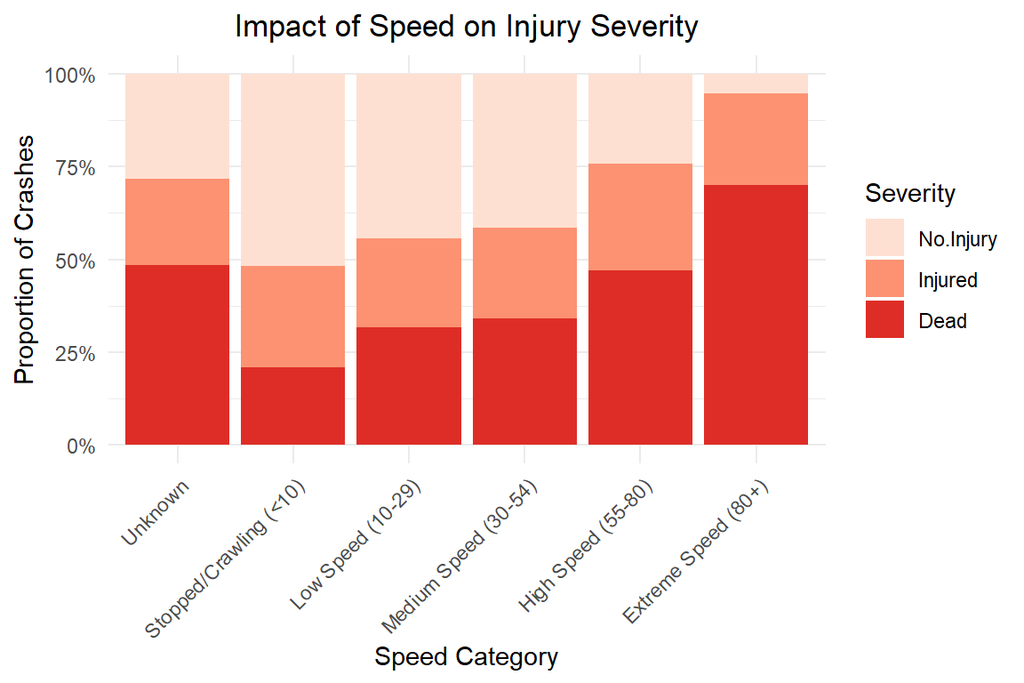

# 6. Models

In this section, we evaluate a set of complementary classification models to predict driver injury severity using the preprocessed, leak-safe dataset. Our objective is not only to maximize predictive performance, but to assess how different modeling assumptions interact with the structure of crash data and to understand the stability of results across model classes.

We begin with multinomial logistic regression as a transparent baseline that provides interpretable class-specific effects and establishes a benchmark under linear decision boundaries. Regularized models (LASSO and Ridge) extend this framework by addressing multicollinearity and high-dimensional feature spaces created through dummy encoding, allowing us to assess whether shrinkage or feature selection improves generalization. k-Nearest Neighbors serves as a non-parametric alternative that captures local similarity patterns without imposing functional form assumptions, while random forests model nonlinear interactions and complex feature dependencies that are common in crash dynamics.

By comparing these models under a consistent preprocessing and evaluation framework, we assess whether gains in flexibility translate into meaningful performance improvements and whether prediction accuracy is driven by model choice or by structural limits of the available information.

## 6.1 Multiclass Modeling

### Multinomial Logit (baseline)

The multinomial logistic regression serves as a natural baseline model. The confusion matrix shows a clear and consistent pattern: “No Injury” and “Dead” are predicted relatively well, while “Injured” is frequently confused with both neighboring classes. This indicates that extreme outcomes are easier to separate, whereas intermediate injury severity is more heterogeneous. Overall accuracy is moderate, but the model provides a transparent benchmark for understanding the structure of misclassification in the data.

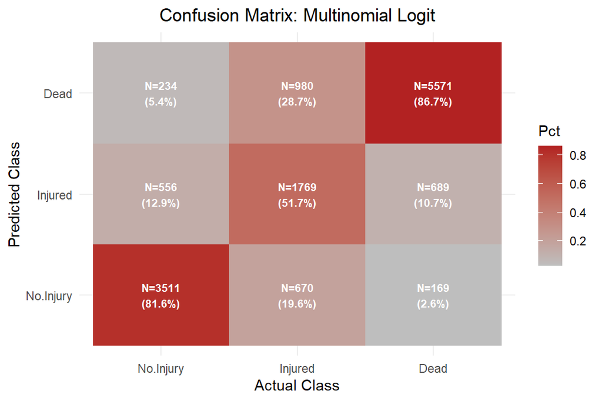

### LASSO

Compared to the baseline logit, the lasso model achieves slightly higher accuracy, mainly by making more confident predictions for the dominant classes. However, the overall error structure remains very similar. Performance on the “Injured” class does not improve meaningfully, suggesting that regularization helps stabilize predictions but does not fundamentally change class separability. Notice that across all three outcomes, Lasso keeps all of the variables. This suggests that each variable contains some information relevant to the predictor. As we can see, the lambda that minimizes the misclassification rate is lambda =0, which is our baseline linear model without any penalty. This suggests that the additional bias introduced via penalized regression actually does not reduce the variance enough to justify its usage versus a multinomial logistic regression

```
--- LASSO GLOBAL FEATURE SELECTION ---
```

```
Total Variables Provided:  60
```

```
Variables Kept:            60
```

```
Variables Dropped:         0
```

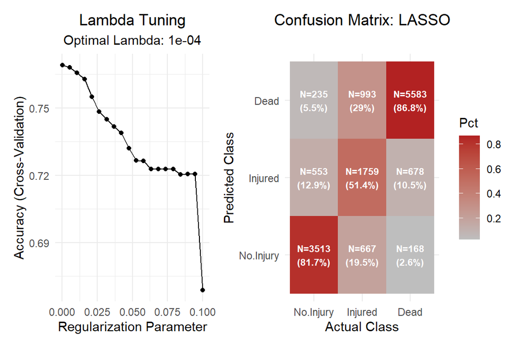

### Ridge

Ridge regression performs very similarly to lasso. Differences in accuracy are marginal, and the confusion matrix closely mirrors that of the multinomial logit. Ridge tends to distribute weight more evenly across predictors, but this does not translate into a clear advantage for predicting intermediate injury severity.

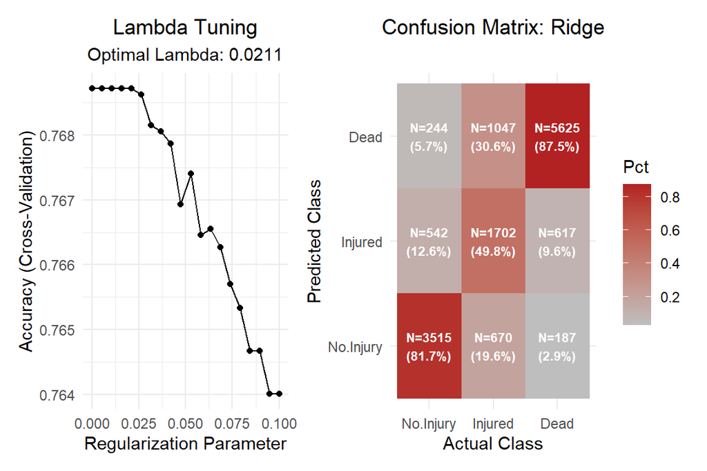

### kNN

kNN shows lower overall accuracy compared to the linear models. It performs worse in distinguishing between injury categories, particularly for the “Dead” class, indicating sensitivity to noise and overlapping feature space. This suggests that distance-based similarity alone is insufficient to capture the complexity of injury severity patterns in the data. Note that for kNN, we only use a subsample of our training date (50%) for computational limits, since kNN computes euclidean distances between points. We still use the same test-data to compare our results, giving a fair comparison between the rest of our models.

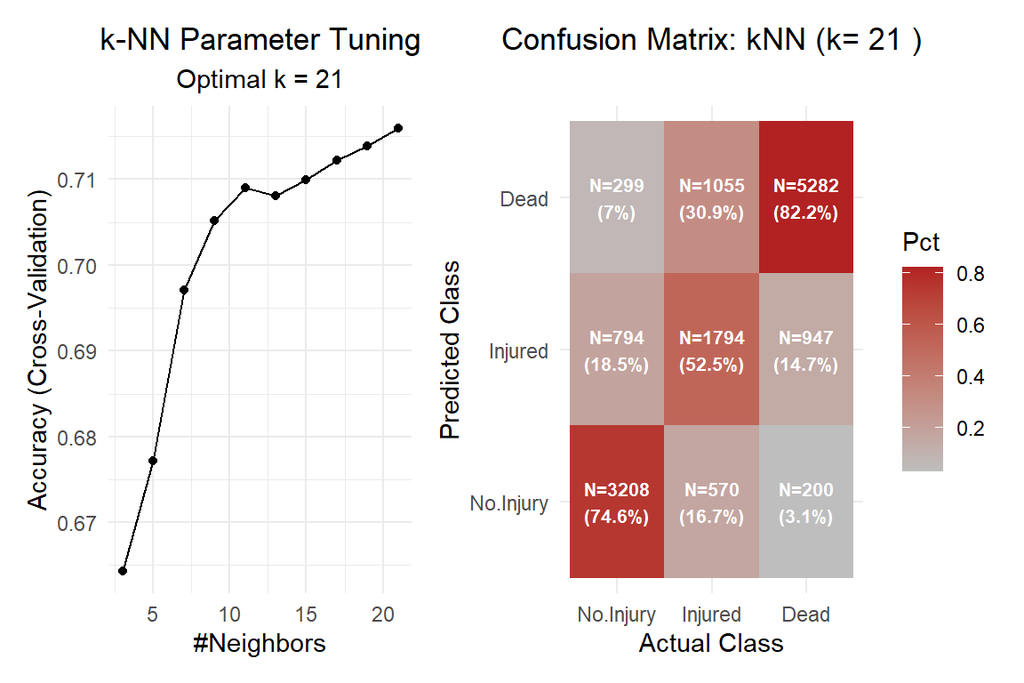

### Random Forests

The random forest does not substantially outperform simpler models. While it captures some nonlinear relationships, its confusion matrix shows the same dominant misclassification pattern, especially for the “Injured” class. Gains over linear models are limited, indicating that higher model complexity does not unlock significantly more predictive signal. We notice that there seems to be a flattening after ~60 trees, so we set our `ntree` parameter to 100 since there isn’t a noticable improvement in performance after this point.

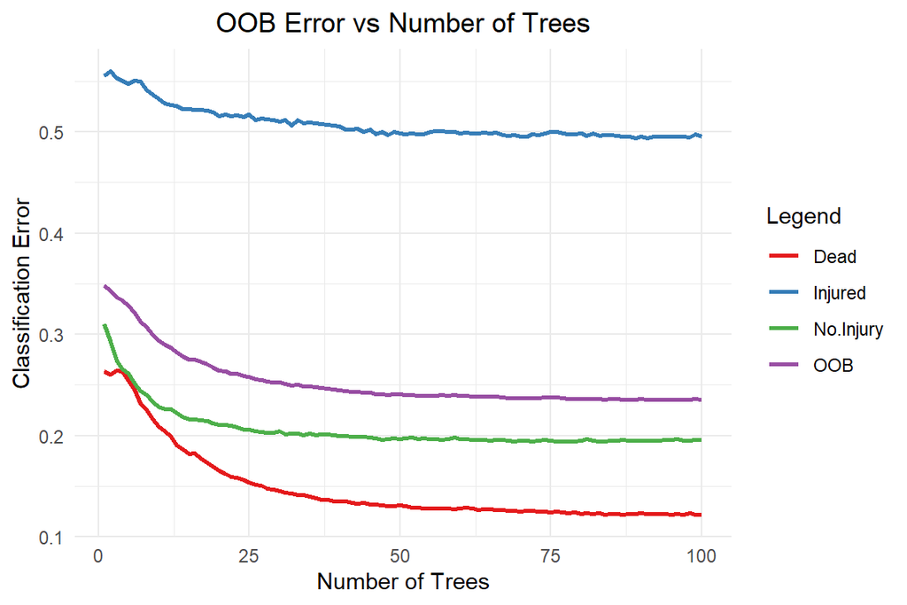

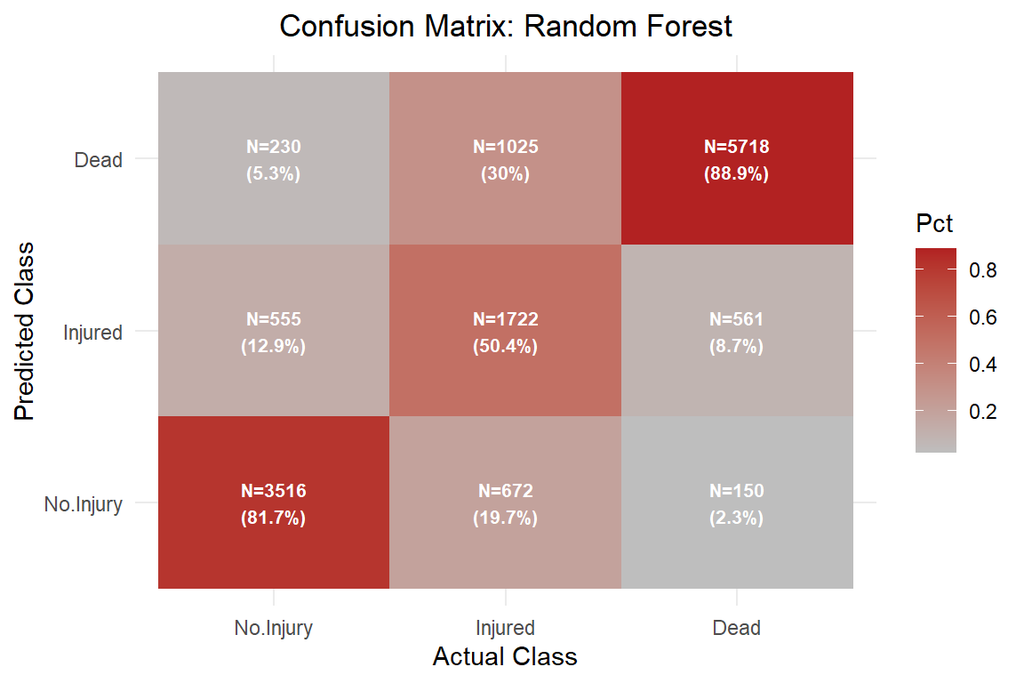

## Results

### Balanced Accuracy.

Balanced accuracy measures performance by first calculating how well the model predicts each injury category separately and then averaging these results. Unlike overall accuracy, it gives equal importance to all classes, which makes it a more truthful measure when some outcomes occur much more frequently than others, as is the case for injury severity. Although the injury severity classes are unevenly distributed, balanced accuracy closely tracks overall accuracy across all models. This indicates that higher accuracy is not achieved by favoring the most common outcomes, but reflects broadly consistent performance across injury categories. In practice, this confirms that differences between models are mainly due to changes in prediction confidence rather than shifts in how errors are distributed across severity levels.

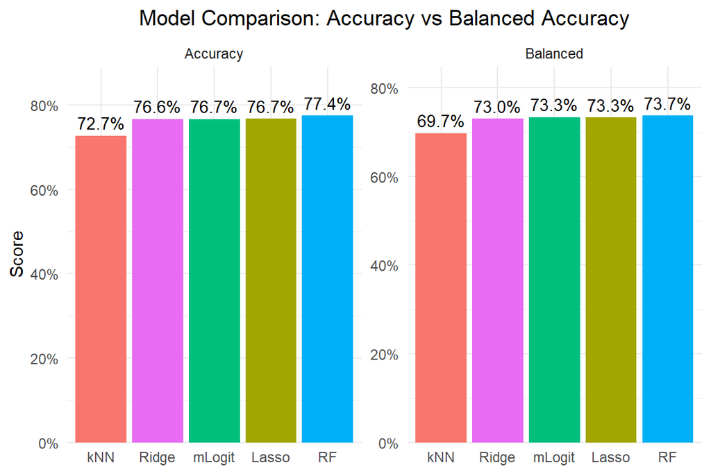

### Overall comparison and conclusions

Across all models, confusion matrices are remarkably similar. Extreme outcomes (“No Injury” and “Dead”) are consistently predicted better than intermediate injuries, which remain difficult to classify. More complex models do not meaningfully change this pattern, suggesting that limitations are driven primarily by data structure rather than modeling technique. Regularized linear models offer a strong balance between performance, stability, and interpretability, while additional complexity yields diminishing returns.

## 6.2 Upsampling

```
No.Injury   Injured      Dead
    19149     19149     19149
```

### LASSO

```
--- LASSO GLOBAL FEATURE SELECTION ---
```

```
Total Variables Provided:  60
```

```
Variables Kept:            60
```

```
Variables Dropped:         0
```

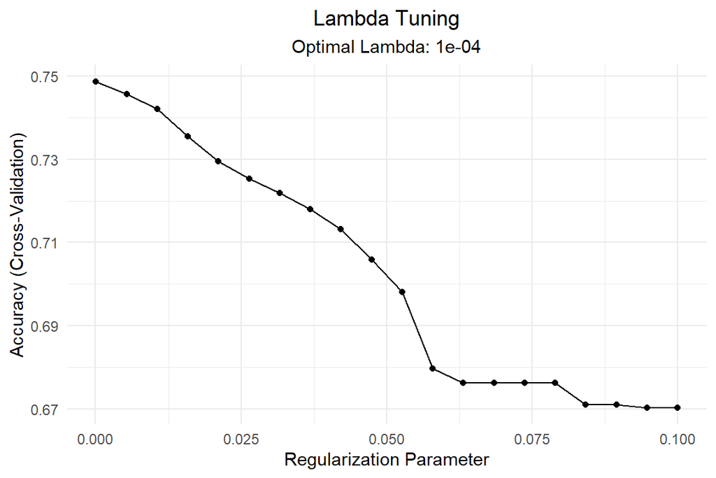

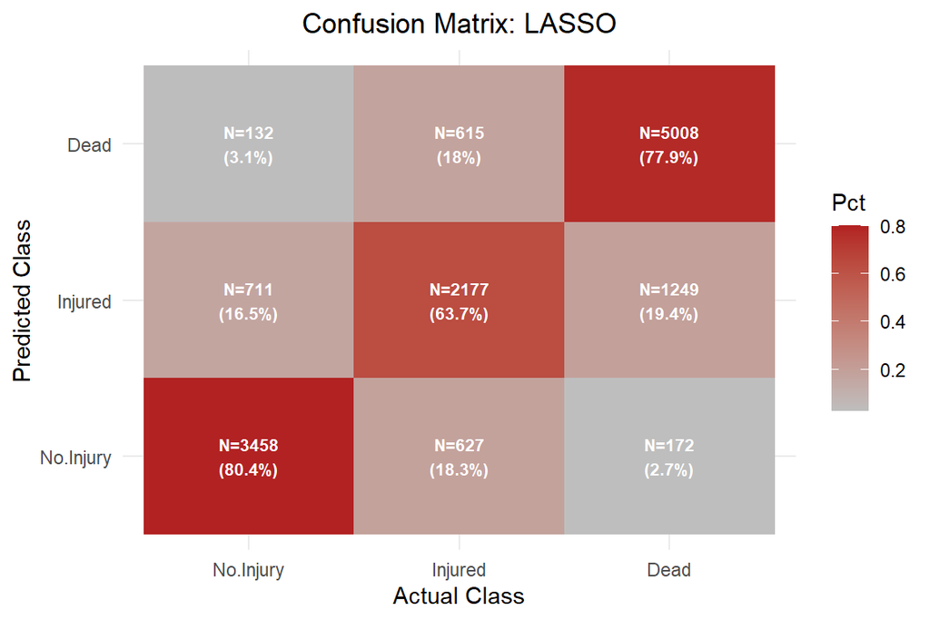

### Random Forest

For the random forest, upsampling leads to similar trade-offs. While predictions for the intermediate injury category improve slightly, performance for the extreme outcomes deteriorates. The confusion matrix indicates that upsampling increases uncertainty in cases that were previously classified with high confidence. Overall, the structure of errors remains consistent with the non-upsampled model.

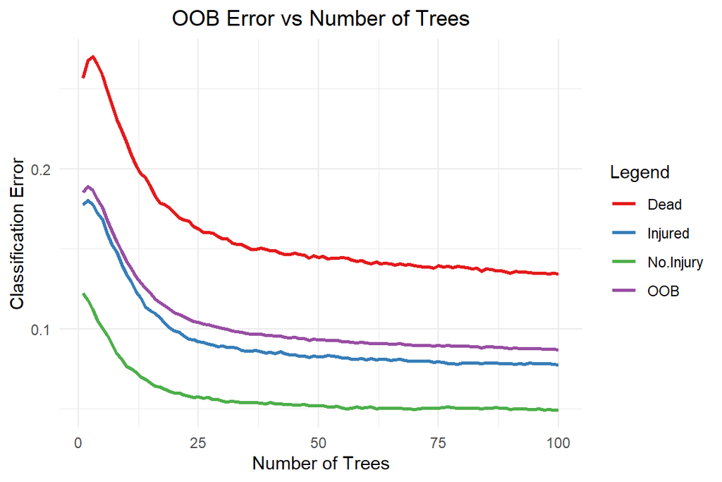

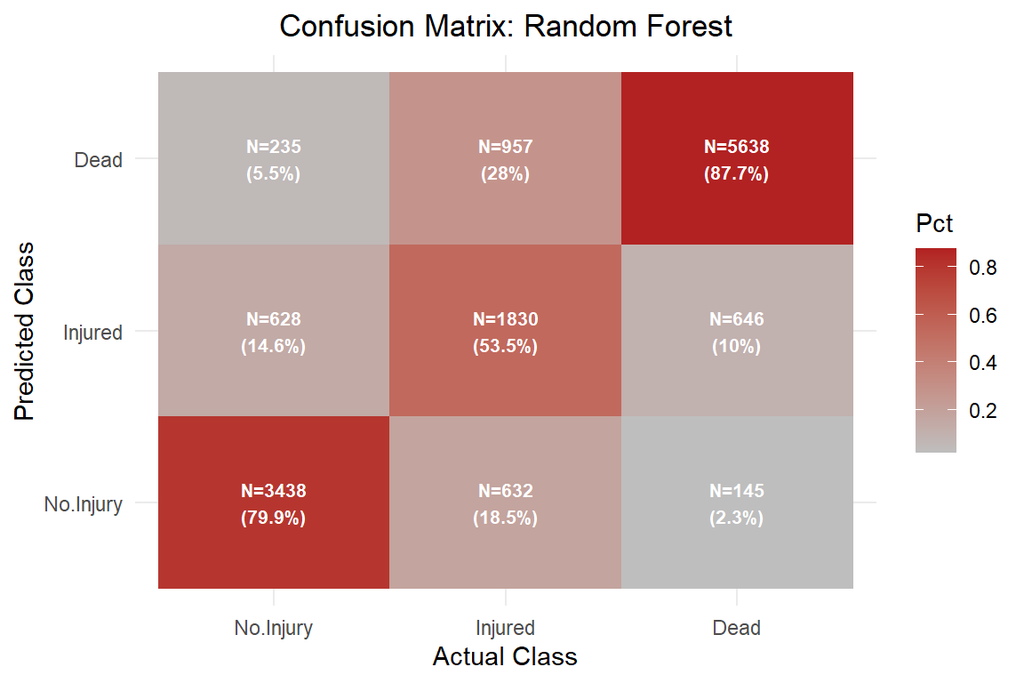

## Results

### Accuracy vs. balanced accuracy

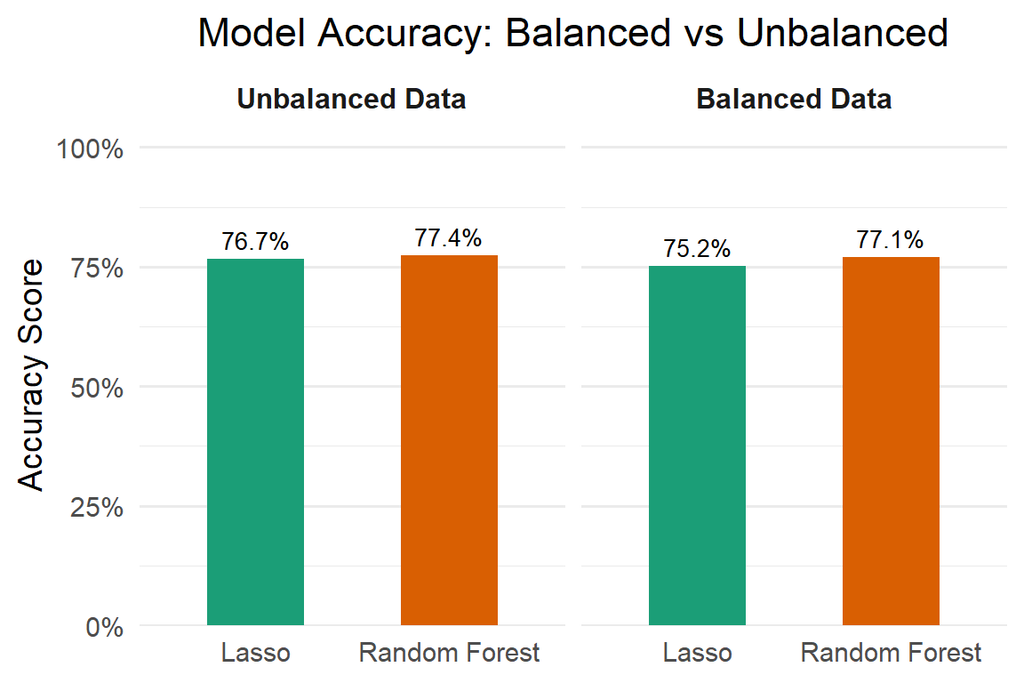

## 6.3 Binary outcome: Fatal vs. Non-Fatal

In the multiclass setting, model performance was primarily limited by difficulty in separating the intermediate “Injured” category from adjacent severity levels. This middle category exhibited substantial overlap in characteristics with both non-injury and fatal outcomes, leading to persistent misclassification across models. To assess how model performance changes when the target separation is clearer, we reformulate the outcome as a binary variable distinguishing fatal versus non-fatal crashes. This transformation also naturally reduces class imbalance without relying on resampling techniques. As earlier experiments with upsampling did not improve performance and introduced trade-offs between classes, the binary framing allows us to evaluate model behavior under a more balanced outcome distribution while preserving the original data structure. As in the multiclass analysis, we focus on comparable linear and non-parametric models to assess whether clearer outcome definitions lead to improved discrimination and more meaningful differences between modeling approaches.

```
# A tibble: 2 × 3
  INJ_SEV       n  prop
  <fct>     <int> <dbl>
1 Non_Fatal 31019  54.8
2 Fatal     25578  45.2
```

### Logit

In the binary setting, logistic regression shows a clear improvement relative to the multiclass case. The model achieves high sensitivity for non-fatal crashes, correctly identifying a large share of survivable outcomes, while maintaining reasonable sensitivity (recall) for fatal crashes. Compared to the three-class setting, where misclassification was driven by overlap with the intermediate “Injured” category, the binary formulation allows the model to focus on a single decision boundary. Although direct metric comparisons are limited, the confusion structure indicates fewer false positives for fatal outcomes and more stable classification overall.

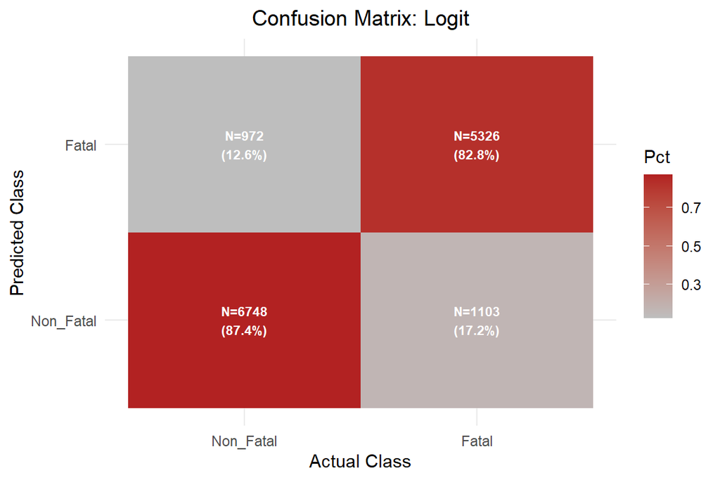